# Solutions — Session 12: A Short Worked Report

M731 · Full worked walkthrough (companion to session-12.qmd)

Author

Shay Abbasi

## Purpose

Session 12 is about reporting mechanics (report structure, chart design, Quarto features), not a new dataset or technique. This solutions file is a **short, complete example report** built on `maritime_survey.csv` — a template you can adapt directly for your own project’s written report. It demonstrates the `gt` table pattern and Quarto cross-references shown in the slide deck.

## Setup

```r
library(tidyverse)
library(gt)

survey <- read_csv("data/maritime_survey.csv")
```

## Executive summary (worked example)

> Maritime Roast is considering entry into the Ontario market. Analysis of the Wk 6-11 survey work finds that Discovery-tier subscribers are the most satisfied segment, and Atlantic subscribers report higher willingness-to-pay than Ontario prospects. **Recommendation**: enter Ontario with an entry-tier (Standard-equivalent) price point and a clear upgrade path toward Discovery, rather than importing Atlantic pricing directly.

## Finding 1 — Satisfaction by tier (table)

```r
survey |>
  group_by(tier) |>
  summarise(
    n = n(),
    mean_sat = mean(satisfaction, na.rm = TRUE),
    sd_sat = sd(satisfaction, na.rm = TRUE),
    .groups = "drop"
  ) |>
  gt() |>
  tab_header(title = "Satisfaction by subscription tier") |>
  fmt_number(columns = c(mean_sat, sd_sat), decimals = 2) |>
  cols_label(tier = "Tier", n = "N", mean_sat = "Mean satisfaction", sd_sat = "SD")
```

Table 1: Satisfaction by subscription tier

Satisfaction by subscription tier

| Tier | N | Mean satisfaction | SD |
| --- | --- | --- | --- |
| Discovery | 147 | 6.29 | 1.01 |
| Signature | 270 | 5.86 | 1.18 |
| Standard | 383 | 5.64 | 1.07 |

See Table 1. Discovery subscribers report the highest mean satisfaction, consistent with the Week 7 ANOVA finding.

## Finding 2 — WTP by region (cross-referenced figure)

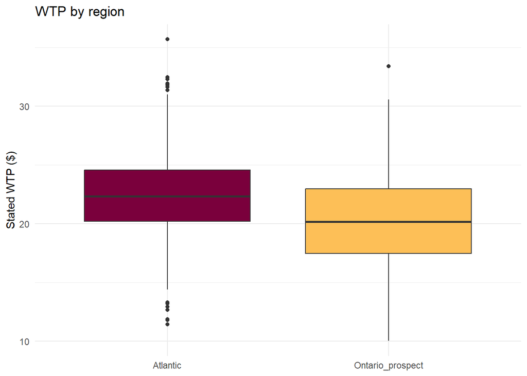

Figure 1: Willingness-to-pay by region

```r
survey |>
  ggplot(aes(x = region, y = wtp, fill = region)) +
  geom_boxplot(show.legend = FALSE) +
  scale_fill_manual(values = c("#7A003C", "#FDBF57")) +
  labs(title = "WTP by region", x = NULL, y = "Stated WTP ($)") +
  theme_minimal()
```

Figure 1 shows Ontario prospects reporting somewhat lower WTP than the existing Atlantic base — see the Week 6 solutions (`solutions-06.qmd`) for the formal hypothesis test and effect size behind this figure.

## Limitations (always include at least 2-3)

- Willingness-to-pay is **stated**, not revealed — actual purchase behaviour after an Ontario launch may differ from survey responses.
- The survey sample is instructor-simulated for this course; a real launch decision would need fielded primary data with a documented sampling frame (see Week 3).
- This report covers only satisfaction and WTP; it does not address awareness, competitive positioning, or logistics/shipping costs into Ontario.

## Take-away for students

This is the minimum shape of a decision-oriented finding: **headline → evidence (table or chart) → interpretation → link back to the underlying analysis.** Your project report should have 3-8 findings in this shape, followed by recommendations that clearly follow from them, and a limitations section that names real gaps rather than boilerplate disclaimers.